# Lecture 6 单变量正态性检验

Hongwei Shi

2021-10-20

**为什么要进行正态性检验 (Normality Test)？**

- 正态分布/高斯分布是统计中最重要的分布，因为很多自然现象都服从正态分布，如血压、身高、测量误差、回归残差、学生成绩等；
- 大多数参数检验 (e.g., correlation, regression, t-test, analysis of variance (ANOVA), Pearson’s correlation coefficient) 的一个可靠假设是数据近似服从正态分布。如果一组数据是非正态的，则通常需要采用非参数的检验方法 (e.g. Mann-Whitney test, Spearman’s correlation coefficient)，这将是更复杂的；
- 正态分布具有很多优良的性质，中心极限定理 (CLT) 指出，在温和的条件下，从同一分布中独立得到的许多随机变量的均值近似正态分布，而与原始分布的形式无关；

```r
# 检查并下载依赖的R packages
need.pakgs <- c("ggpubr", "plyr", "ggplot2", "nortest",
                "tseries", "moments", "DescTools")
has <- need.pakgs %in% rownames(installed.packages())
if(any(!has)) install.packages(need.pakgs[!has])
```

# 图示检验法

```r
# 生成两组数据
n <- 100
data.norm <- rnorm(n) # 正态分布
data.f <- rf(n, 10, 10) # F分布
```

## 直方图和密度估计

- 直方图和密度图可以直观地判断数据分布是否呈钟形。

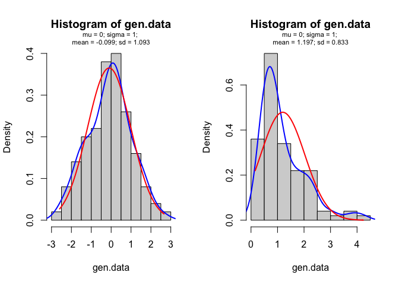

```r
grap_test <- function(gen.data) {
  # 直方图和密度估计
  hist(gen.data, freq=FALSE)
  lines(density(gen.data), col="blue", lwd=2)
  # 添加正态密度
  curve(dnorm(x, mean=mean(gen.data), sd=sd(gen.data)),
        from=min(gen.data), to=max(gen.data),
        col="red", lwd=2, add=TRUE)
  mtext(paste0("mu = 0; sigma = 1; ", "\n",
               "mean = ", round(mean(gen.data),3),
               "; sd = ", round(sd(gen.data),3)), side=3, cex=0.7)
}
par(mfrow=c(1, 2))
grap_test(data.norm) ;grap_test(data.f)
```

采用R package: ggplot2

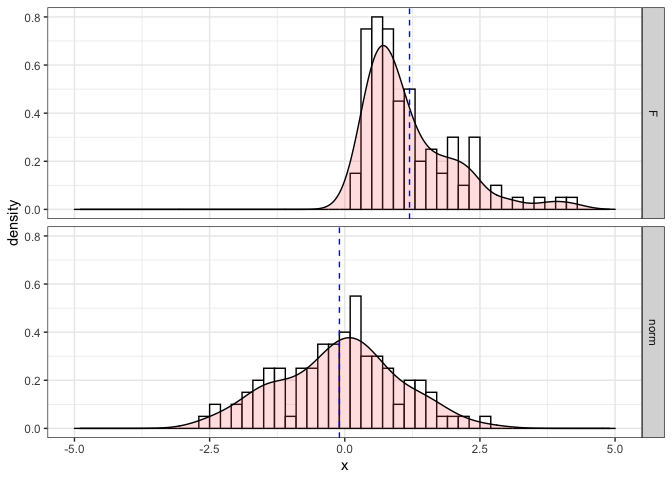

```r
library(plyr)
library(ggplot2)
df <- data.frame(x=c(data.norm, data.f),
                 type=factor(rep(c("norm", "F"), each=n)))
mu <- ddply(df, "type", summarise, grp.mean=mean(x))

ggplot(df, aes(x=x)) +
  geom_histogram(aes(y=..density..), binwidth=0.2, colour="black", fill="white") +
  scale_x_continuous(limits=c(-5, 5)) +
  geom_density(alpha=.2, fill="#FF6666") +
  geom_vline(data=mu, aes(xintercept=grp.mean), color="blue",
             linetype="dashed") + # 添加均值线
  facet_grid(type ~ .) +
  theme_bw()
```

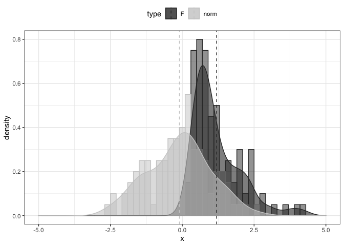

```r
ggplot(df, aes(x=x, fill=type, color=type)) +
  geom_histogram(aes(y=..density..), binwidth=0.2, position="identity", alpha=0.5) +
  geom_density(alpha=0.6) +
  scale_x_continuous(limits=c(-5, 5)) +
  geom_vline(data=mu, aes(xintercept=grp.mean, color=type),
             linetype="dashed") + # 添加均值线
  scale_color_grey() +
  scale_fill_grey() +
  theme_bw() +
  theme(legend.position="top") # 标签放置在顶部
```

采用R package: ggpubr

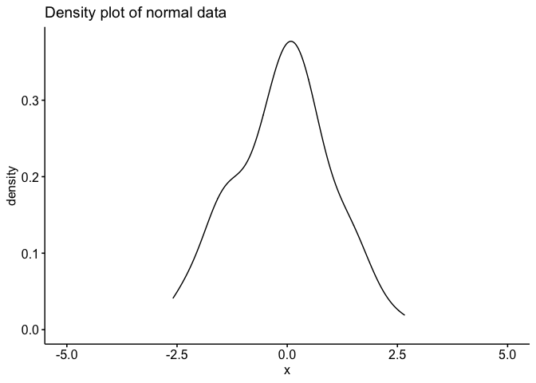

```r
library(ggpubr)
ggdensity(data.norm, xlim=c(-5, 5), main = "Density plot of normal data")
```

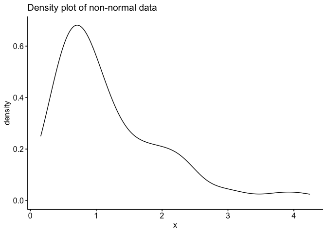

```r
ggdensity(data.f, main = "Density plot of non-normal data")
```

## Q-Q plot & P-P plot

### Q-Q Plot

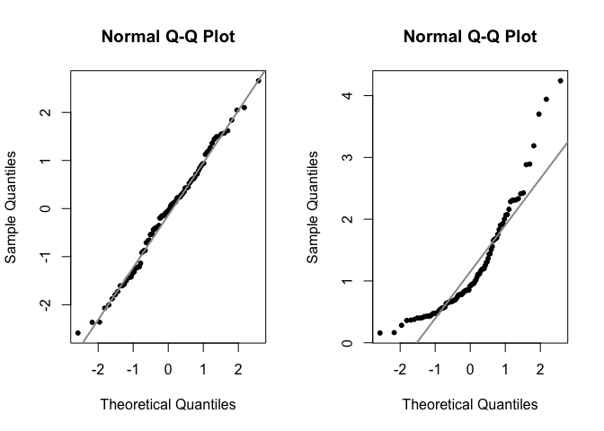

```r
qq_test <- function(gen.data) {
  qqnorm(gen.data, pch=20, cex=1)
  qqline(gen.data, col="gray60", lwd=2)
}
par(mfrow=c(1, 2))
qq_test(data.norm) ;qq_test(data.f)
```

尝试自己用函数实现Q-Q plot

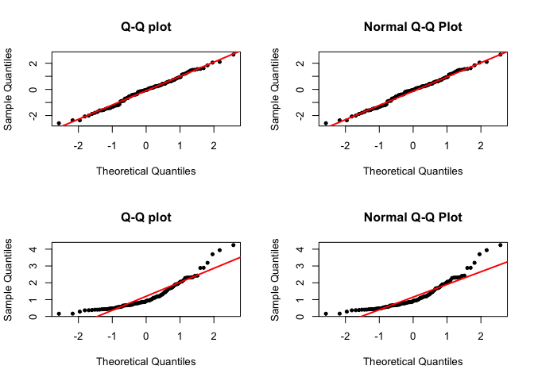

```r
qq_func <- function(gen.data) {
  sample.quan <- qnorm((rank(gen.data) -0.5)/length(gen.data)) # -0.5是常用的修正方法
  plot(sample.quan, gen.data, pch=20, cex=1,
       xlab="Theoretical Quantiles", ylab="Sample Quantiles",
       main="Q-Q plot")
  # # 快速计算累积百分数
  # sample.quan <- qnorm(ppoints(length(gen.data)))
  # plot(sample.quan, sort(gen.data), pch=20, cex=1,
  #      xlab="Theoretical Quantiles", ylab="Sample Quantiles",
  #      main="Q-Q plot")

  abline(mean(gen.data), sd(gen.data), col="red", lwd=2)
  # 利用qqnorm函数
  qqnorm(gen.data, pch=20, cex=1)
  qqline(gen.data, col="red", lwd=2)
}
par(mfrow=c(2, 2))
qq_func(data.norm); qq_func(data.f)
```

同时Q-Q图还可以检验两组数据是否来自同一个分布

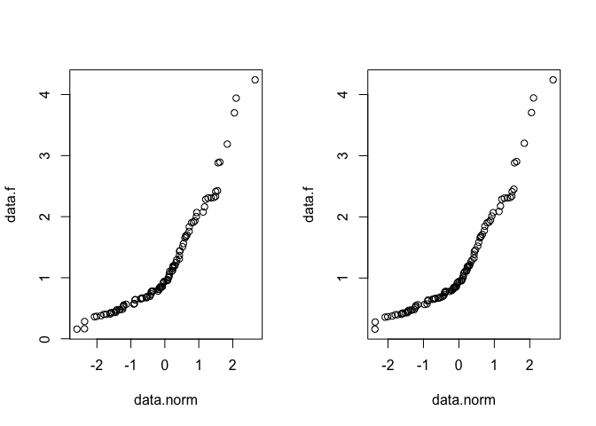

```r
par(mfrow=c(1, 2))
qqplot(data.norm, data.f) # 其实就是两组数据分位数的散点图
# plot(quantile(data.norm, seq(0, 1, by=0.001)),
#      quantile(data.f, seq(0, 1, by=0.001)),
#      xlab="data.norm", ylab="data.f")
plot(quantile(data.norm, sort(rank(data.norm)/length(data.norm))),
     quantile(data.f, sort(rank(data.f)/length(data.f))),
     xlab="data.norm", ylab="data.f")
```

car包绘制QQ图及95%置信区间

```r
library("car")
par(mfrow=c(1, 2))
qqPlot(data.norm, main="Q-Q plot", col="blue", col.lines="red")
```

```
## [1] 87 53
```

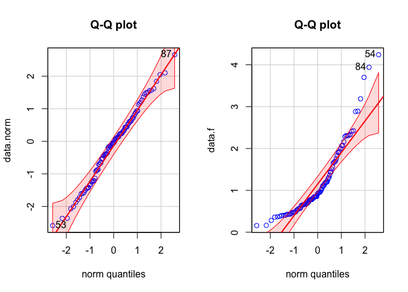

```
## [1] 54 84
```

```r
qqPlot(data.f, main="Q-Q plot", col="blue", col.lines="red")
```

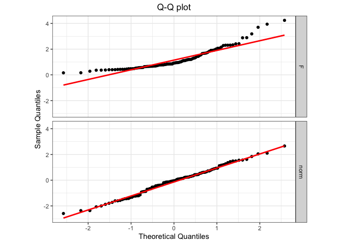

```r
# ggplot2
library(ggplot2)
ggplot(df, aes(sample=x)) +
  geom_qq() +
  geom_qq_line(size=1, color="red", ) +
  facet_grid(type ~ .) +
  labs(x="Theoretical Quantiles", y="Sample Quantiles", title="Q-Q plot") +
  theme_bw() +
  theme(plot.title=element_text(hjust=0.5)) + # 标题居中
  coord_fixed(ratio=0.3) # 调整纵横比
```

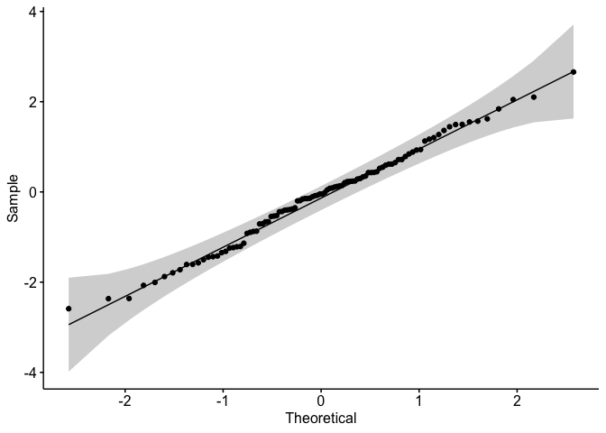

```r
# ggpubr
library(ggpubr)
ggqqplot(data.norm)
```

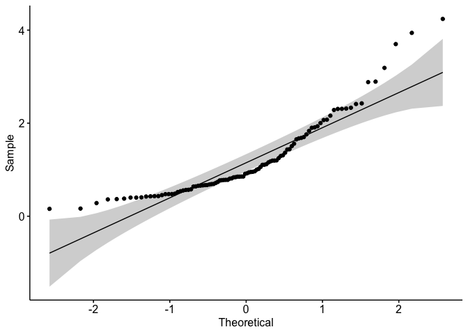

```r
ggqqplot(data.f)
```

### P-P plot

- 横轴为实际累积概率，纵轴为理论分布累积的概率，标准直线为 $y=x$

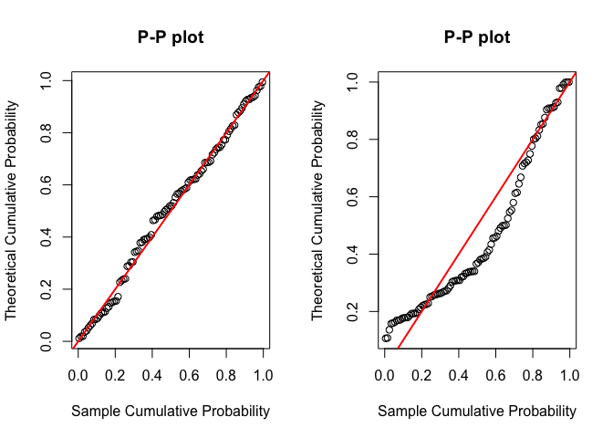

```r
pp_test <- function(gen.data) {
  sample.quan <- (rank(gen.data)-0.5)/length(gen.data)
  plot(sample.quan, pnorm(mean=mean(gen.data), sd=sd(gen.data), gen.data),
       xlab="Sample Cumulative Probability", ylab="Theoretical Cumulative Probability",
       main="P-P plot")
  abline(0, 1, col="red", lwd=2)
}
par(mfrow=c(1, 2))
pp_test(data.norm); pp_test(data.f)
```

# 统计量检验法

- 参考文章: [Comparisons of various types of normality tests](https://www.tandfonline.com/doi/pdf/10.1080/00949655.2010.520163?needAccess=true)
- $H_{0}: f(x, \Theta) \in N\left(\mu, \sigma^{2}\right)$ vs $H_{1}: f(x, \Theta) \notin N\left(\mu, \sigma^{2}\right)$

## Moments

### Jarque–Bera (JB) test

- 来自 `tseries` package 的函数 `jarque.bera.test()`

```r
library(tseries)
jarque.bera.test(data.norm)
```

```
##
##  Jarque Bera Test
##
## data:  data.norm
## X-squared = 0.55844, df = 2, p-value = 0.7564
```

```r
jarque.bera.test(data.f)
```

```
##
##  Jarque Bera Test
##
## data:  data.f
## X-squared = 53.865, df = 2, p-value = 2.011e-12
```

```r
# ??JarqueBeraTest
```

### D’Agostino test

```r
library(moments)
agostino.test(data.norm)
```

```
##
##  D'Agostino skewness test
##
## data:  data.norm
## skew = -0.048304, z = -0.209798, p-value = 0.8338
## alternative hypothesis: data have a skewness
```

```r
agostino.test(data.f)
```

```
##
##  D'Agostino skewness test
##
## data:  data.f
## skew = 1.4630, z = 4.9492, p-value = 7.453e-07
## alternative hypothesis: data have a skewness
```

### Skewness test

常见分布的偏度值：

- Normal distribution has a skewness of 0
- Half-normal distribution has a skewness of just below 1
- Exponential distribution has a skewness of 2
- Lognormal distribution can have a skewness of any positive value, depending on its parameters

```r
n <- 10000
nl <- rnorm(n) # Normal distribution
skewness(nl)
```

```
## [1] 0.02135579
```

```r
rln <- rlnorm(n) # Lognormal distribution
skewness(rln)
```

```
## [1] 5.141755
```

```r
el <- rexp(n) # exponential distribution
skewness(el)
```

```
## [1] 2.046103
```

```r
# ??Skew
```

### Kurtosis test

- 任何一元正态分布的峰度都是3

```r
n <- 10000
nl <- rnorm(n) # Normal distribution
kurtosis(nl)
```

```
## [1] 3.00416
```

```r
rln <- rlnorm(n) # Lognormal distribution
kurtosis(rln)
```

```
## [1] 54.26995
```

```r
el <- rexp(n) # exponential distribution
kurtosis(el)
```

```
## [1] 8.907842
```

```r
# ??Kurt
library(DescTools)
Kurt(nl, method=2) # 函数中已经-3，接近0为正态分布
```

```
## [1] 0.00476274
```

## Empirical distribution test

### Kolmogorov-Smirnov (KS) test

```r
ks.test(data.norm, "pnorm", mean=mean(data.norm),
        sd=sd(data.norm), alternative="two.sided")
```

```
##
##  One-sample Kolmogorov-Smirnov test
##
## data:  data.norm
## D = 0.06384, p-value = 0.8097
## alternative hypothesis: two-sided
```

```r
ks.test(data.norm, "pnorm", mean=3,
        sd=10, alternative="two.sided")
```

```
##
##  One-sample Kolmogorov-Smirnov test
##
## data:  data.norm
## D = 0.5258, p-value < 2.2e-16
## alternative hypothesis: two-sided
```

### Lilliefors (LL) test

- LL test is a modification of KS test

```r
# ??lillie.test
# ??LillieTest

library(nortest)
lillie.test(data.norm)
```

```
##
##  Lilliefors (Kolmogorov-Smirnov) normality test
##
## data:  data.norm
## D = 0.06384, p-value = 0.404
```

```r
lillie.test(data.f)
```

```
##
##  Lilliefors (Kolmogorov-Smirnov) normality test
##
## data:  data.f
## D = 0.15933, p-value = 1.417e-06
```

### Cramer–von-Mises (CVM) test

```r
library(nortest)
cvm.test(data.norm)
```

```
##
##  Cramer-von Mises normality test
##
## data:  data.norm
## W = 0.049889, p-value = 0.5084
```

```r
cvm.test(data.f)
```

```
##
##  Cramer-von Mises normality test
##
## data:  data.f
## W = 0.73922, p-value = 3.238e-08
```

```r
# ??CramerVonMisesTest
```

### Anderson–Darling (AD) test

```r
library(nortest)
ad.test(data.norm)
```

```
##
##  Anderson-Darling normality test
##
## data:  data.norm
## A = 0.28919, p-value = 0.6081
```

```r
ad.test(data.f)
```

```
##
##  Anderson-Darling normality test
##
## data:  data.f
## A = 4.1977, p-value = 1.653e-10
```

```r
# ??AndersonDarlingTest
```

## Spacings

### Rao’s test ++

- 还在探索

### Greenwood test ++

- 还在探索

## Regression and Correlation

### Shapiro–Wilk (SW) test

```r
shapiro.test(data.norm)
```

```
##
##  Shapiro-Wilk normality test
##
## data:  data.norm
## W = 0.99162, p-value = 0.7934
```

```r
shapiro.test(data.f)
```

```
##
##  Shapiro-Wilk normality test
##
## data:  data.f
## W = 0.85905, p-value = 2.599e-08
```

### Shapiro–Francia test

- SF test is a modified version of SW test

```r
library(nortest)
sf.test(data.norm)
```

```
##
##  Shapiro-Francia normality test
##
## data:  data.norm
## W = 0.99365, p-value = 0.8606
```

```r
sf.test(data.f)
```

```
##
##  Shapiro-Francia normality test
##
## data:  data.f
## W = 0.85858, p-value = 2.213e-07
```

### Ryan–Joiner tests ++

- 还在探索

## Pearson $\chi^2$ test

- 《Comparisons of various types of normality tests》中 section 2.3 讨论了 Pearson’s chi-squared (CSQ) goodness-of-fit test

```r
library(nortest)
pearson.test(data.norm)
```

```
##
##  Pearson chi-square normality test
##
## data:  data.norm
## P = 13.1, p-value = 0.2181
```

```r
pearson.test(data.f)
```

```
##
##  Pearson chi-square normality test
##
## data:  data.f
## P = 52.88, p-value = 7.838e-08
```

```r
# ??PearsonTest
```

# 不同单变量正态性检验方法的对比研究

- 课上尝试

[figure not shown]